# Introduction to dplyr

# Some examples of tidying up model output for later (really this section is just for reference for later).

We don’t have time to go into some of the fancier functionality but I wanted to include it so you have the code. *dplyr* has a few complementary packages that make model outputs clean and tidy. Guess what the packages are called - *tidyr* and *broom* (these people are so clever).

So install and load these packages first

Model output can take up lots of space, but often times you don’t care about lots of the output. So a more tidy way to look at model results would be good. As a reminder, first let’s look at a normal linear model output. Let’s look at the relationship between wtcpue and btemp for pollock in 2005.

```r
lm1 <- lm(wtcpue~btemp,data=trawl[trawl$sid==21740 & trawl$year==2005,])
summary(lm1)
```

Now using the **do()** function we can pipe a dataset into a linear model, saving both the model and the row. There is one funky convention we haven’t talked about and that is “.” - which is a way to tell R to use the dataset that has already been referenced in this row. This is one of those places where the intersection between *dplyr* and base R gets a little murky. Remember *dplyr* functions reference the data at the beginning but lots of base R functions do so at the end. In order to still use the results of any filtering, selecting, arranging, joining, etc., that you may have already done in your line of code, we just put a “.” where the “data=” would normally be.

```r
tidylm1 <- filter(trawl,sid==21740 & year==2005) %>% do(lm1=(lm(wtcpue~btemp,.)))
```

```r
tidy(lm1)
```

Often, we don’t have any interest in saving the model object so we can nest the **tidy** within the **do** to just print the output.

```r
trawl %>% filter(sid==21740 & year==2005) %>% do(tidy(lm(wtcpue~btemp,.)))
```

And of course, we can pipe in other dplyr functions like, **group_by** to model multiple years, for example

```r
trawl %>%
  filter(sid==21740) %>%
  group_by(year) %>%
  do(tidy(lm(wtcpue~btemp,.)))

#  Remember if we want to see all of the results we can convert the output to a data.frame
trawl %>%
  filter(sid==21740) %>%
  group_by(year) %>%
  do(tidy(lm(wtcpue~btemp,.))) %>%
  data.frame
```

This format makes it really easy to plot model outputs because they are in a tidy data frame. For example, if we wanted to plot the btemp coefficient by year we could do the following

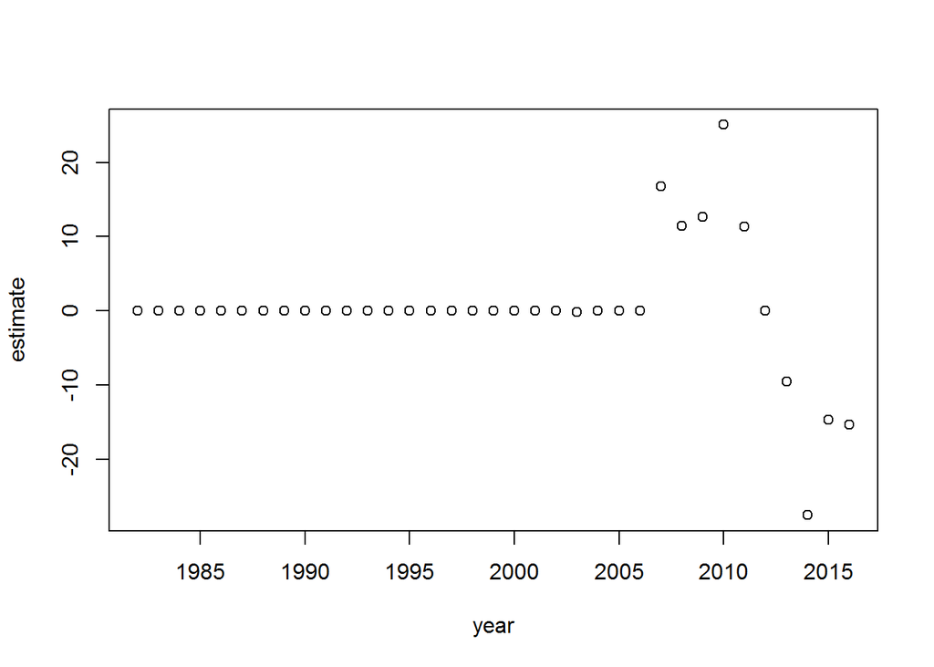

```r
trawl %>%
  filter(sid==21740) %>%
  group_by(year) %>%
  do(tidy(lm(wtcpue~btemp,.)))

#  Note that every other row has btemp in the "term" column,
#  so we want to filter the data frame by btemp
trawl %>%
  filter(sid==21740) %>%
  group_by(year) %>%
  do(tidy(lm(wtcpue~btemp,.))) %>%
  filter(term=="btemp")

my.df <-
  trawl %>%
  filter(sid==21740) %>%
  group_by(year) %>%
  do(tidy(lm(wtcpue~btemp,.))) %>%
  filter(term=="btemp")

plot(estimate~year,data=my.df)
```

Alternatively, if we didn’t want the extra step of saving my.df, we could just stick the whole thing into the plot function.

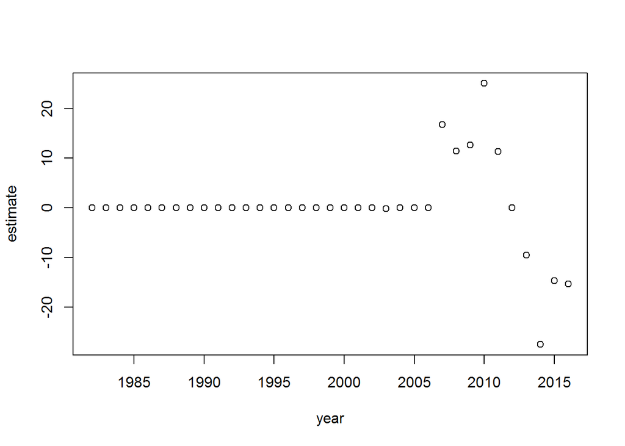

```r
plot(estimate~year,
     data=(trawl %>%
             filter(sid==21740) %>%
             group_by(year) %>%
             do(tidy(lm(wtcpue~btemp,.))) %>%
             filter(term=="btemp")))
```

One last example, using gams. There are a few custom functions within *broom* that organize model outputs in different ways: **glance**,**augment**,**tidy**. Here are some examples. Note that we still use the “.” convention.

```r
#  Load the gam library mgcv
library(mgcv)
trawl[trawl$sid==21740,] %>%
  group_by(year) %>%
  do(glance(gam(wtcpue~s(btemp),.,family="gaussian")))

trawl[trawl$sid==21740,] %>%
  group_by(year) %>%
  do(augment(gam(wtcpue~s(btemp),.,family="gaussian")))

trawl[trawl$sid==21740,] %>%
  group_by(year) %>%
  do(tidy(gam(wtcpue~s(btemp)+s(depth),.,family="gaussian")))
```

Acknowledgement: This document was one of the many outcomes of the NOAA Fisheries FishSET (Spatial Economics Toolbox for Fisheries) project funded by the NOAA Office of Science and Technology. The views and content expressed in this document do not represent those of the Department of Commerce, the National Oceanic and Atmospheric Administration, the National Marine Fisheries Service, or the Alaska Fisheries Science Center.